# Visualization Analysis (Team-Level)

## Initial Loading

The wrangled data previously created and required modules is loaded.

```python
import pandas as pd
import matplotlib.pyplot as plt
import seaborn as sns
import numpy as np
import scikits.bootstrap as bootstrap
import scipy.stats
from typing import List
regular_season_totals = pd.read_csv("regular_season_totals.csv")
play_off_totals = pd.read_csv("play_off_totals.csv")
regular_season_team_summary_stats = pd.read_csv("regular_season_team_summary_stats.csv")
```

## Visualization Analysis (Team-Level)

The purpose of this component of the project is to analyze basketball performance variables and determine if they may have associations with winning and team performance in basketball. The results from this component will be applied to the statistical modelling component. Specifically, the top 6 variables interpreted to have the strongest association with wins will be selected as the model predictors in the next element in this project.

### Boxplot, Histogram, Bar Chart, and Confidence Interval Analysis

Boxplots are used to compare the total values of all variables among all teams during the regular season. Since there are 30 teams, to make visualizations more readable, 3 side-by-side boxplots will be used. The y-scales will also be monitored closely, since there will be 3 boxplots with different scales. For each variable explored in the boxplots, a team that performs relatively better in the variable and one that performs relatively worse is selected via observation from the boxplots to observe meaningful differences. There is no specific criterion for the selection process, though teams with more extreme means and lower ranges are more favoured to be chosen. For simplicity, play-offs data will not be used.

Then, a histogram showing the distribution of the variable from all games played by the team during the regular season is plotted, along with a bar chart summarizing their wins and losses. Play-offs data is not used to create the histograms and bar charts as there are a lot less observations for each team compared to regular season data. It is then compared whether the higher-performing team in the variable has more wins. In the context of higher-performing in this project, it means a greater score, not necessarily whether or not the score is favourable. The purpose of this part is to have a broader glimpse of the relationship between the variable and winning for each of the teams, and whether or not the variable may be essential to winning. If the lower-performing team has more wins than the higher-performing team, then the variable may not have as strong a relationship with winning as other variables.

Focusing only on games where the higher-performing team beat the lower-performing team, a 95% confidence interval for the true mean difference in the variable between the teams is computed. This is done via bootstrapping 1000 resamples from all games in the sample where that specific winning team beat the specific losing team. Play-offs data is once again not used here due to very limited data. If the interval contains values between -1 and 1, then it is interpreted that winning is not likely to be associated with having higher values in the variable, as it is suggested that both teams have similar overall performance. This is because differences in the basketball performance variables analyzed with magnitudes less than 1 are minimal and do not typically portray the variable as having a meaningful association with winning. However, if the interval contains values greater than 1, it is interpreted that there may be a positive relationship between the variable and winning, as one team does substantially better than the other. Afterwards, a 95% confidence interval for the true mean difference in the variable between the winning and losing teams of all games in each of the regular season and play-offs sample is constructed to potentially solidify the findings from just using the two teams, or to observe pattern deviations. The results from the interval using the regular season sample should be more reliable as the sample size is larger than the play-offs sample, being more representative of the population. Since both sample sizes are much larger than the sample with the two specific teams, their results for the confidence interval are more reliable as there is more precision. The purpose of comparing two teams while also having the ability to use the entire samples of regular season and play-offs games is to further explore the data and identify any outliers or deviations from the overall trends.

```python
#Team names to create boxplots of variables for
teamNames1 = ["Atlanta Hawks","Boston Celtics","Charlotte Hornets","Chicago Bulls","Cleveland Cavaliers",
              "Dallas Mavericks","Denver Nuggets","Detroit Pistons","Golden State Warriors",
              "Houston Rockets"]

teamNames2 = ["Indiana Pacers","Los Angeles Clippers","Los Angeles Lakers","Memphis Grizzlies","Miami Heat",
              "Milwaukee Bucks","Minnesota Timberwolves","Brooklyn Nets","New Orleans Pelicans",
              "New York Knicks"]

teamNames3 = ["Oklahoma City Thunder","Orlando Magic","Phoenix Suns","Portland Trail Blazers","Sacramento Kings",
              "San Antonio Spurs","Toronto Raptors","Washington Wizards","Philadelphia 76ers","Utah Jazz"]

regular_season_team_summary_stats_1 = regular_season_team_summary_stats[regular_season_team_summary_stats["teamName"].isin(teamNames1)]
regular_season_team_summary_stats_2 = regular_season_team_summary_stats[regular_season_team_summary_stats["teamName"].isin(teamNames2)]
regular_season_team_summary_stats_3 = regular_season_team_summary_stats[regular_season_team_summary_stats["teamName"].isin(teamNames3)]

#Regular season totals data split between winning games and losing games
winning_games_regular_season = regular_season_totals[regular_season_totals["WL"] == "W"]
losing_games_regular_season = regular_season_totals[regular_season_totals["WL"] == "L"]

#Play-offs totals data split between winning games and losing games
winning_games_play_offs = play_off_totals[play_off_totals["WL"] == "W"]
losing_games_play_offs = play_off_totals[play_off_totals["WL"] == "L"]

#Function to create boxplots
def plot_boxplot(variable:str,df:pd):
    """
    Plots boxplot of given variable for given data frame df for group of teams,
    assuming the variable exists within df
    """
    plt.figure(figsize=(20,4.8))
    sns.boxplot(x="teamName",y=variable,data=df,color='grey')
    plt.show()
    return

#Function to create histogram
def plot_histogram(variable:str,df:pd):
    """
    Plots histogram of given variable for given data frame df for a team,
    assuming the variable exists within df
    """
    plt.figure(figsize=(20,4.8))
    sns.histplot(x=variable,data=df,bins='auto',color='grey')
    plt.show()
    return

#Function to create bar chart
def plot_barchart(variable:str,df:pd):
    """
    Plots bar chart of given variable for given data frame df for a team,
    assuming the variable exists within df
    """
    plt.figure(figsize=(20,4.8))
    sns.countplot(x=variable,data=df,color='grey')
    plt.show()
    return

def bootstrap_distribution(variable:str,original_sample:pd):
    """
    Performs bootstrap resampling for 1000 samples to explore true mean for given variable of the given original sample,
    assuming the variable exists in given data
    """
    bootstrap_means = []
    for _ in range(1000):
        bootstrap_resample = original_sample[variable].sample(n=len(original_sample),replace=True)
        mean = bootstrap_resample.mean()
        bootstrap_means.append(mean)

    return bootstrap_means

def confidence_interval(data:List[int]):
    """
    Computes lower and upper bounds of 95% confidence interval for given numeric data
    """
    data = pd.Series(data)
    lower_bound = float(data.quantile(0.025))
    upper_bound = float(data.quantile(0.975))
    return [lower_bound,upper_bound]

def visualize_confidence_interval(distribution: None,bounds:List[float]):
    """
    Shades in given 95% confidence interval for given distribution
    """
    sns.histplot(x=distribution,bins=30,color='gray')
    plt.axvspan(bounds[0],bounds[1],alpha=0.3,facecolor="turquoise",edgecolor="red",linewidth=4)
    plt.show()
    return

def score(ci1: List[float],ci2:List[float]):
    """
    Computes score for variable given the method described under "Final Selections"
    """
    return 0.93 * ((ci1[0] + ci1[1])/2)/(ci1[1] - ci1[0]) + 0.07 * ((ci2[0] + ci2[1])/2)/(ci2[1] - ci2[0])
```

Field Goals Made

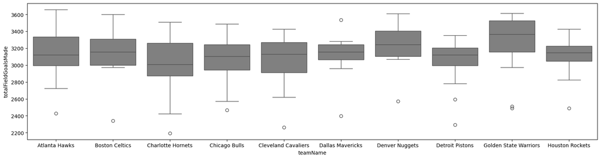

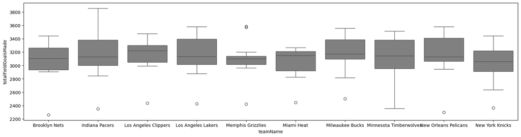

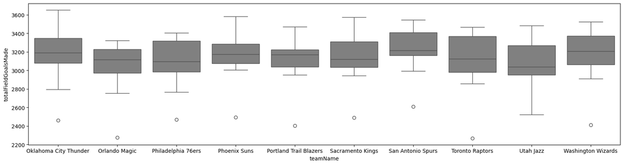

```python
plot_boxplot("totalFieldGoalsMade",regular_season_team_summary_stats_1)
plot_boxplot("totalFieldGoalsMade",regular_season_team_summary_stats_2)
plot_boxplot("totalFieldGoalsMade",regular_season_team_summary_stats_3)
```

Based on the boxplots above, San Antonio Spurs appear to have a higher number of field goals made than most teams and Utah Jazz tends to have a lower number of field goals made. To explore the association of field goals made on game outcomes, a histogram of the field goals made and a bar chart of wins and losses are plotted for each team.

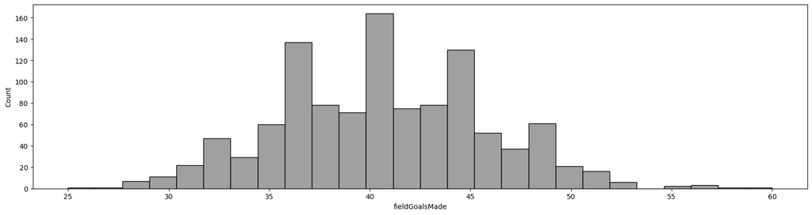

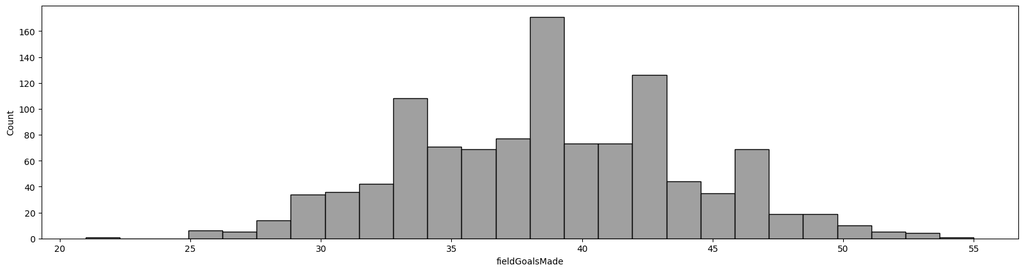

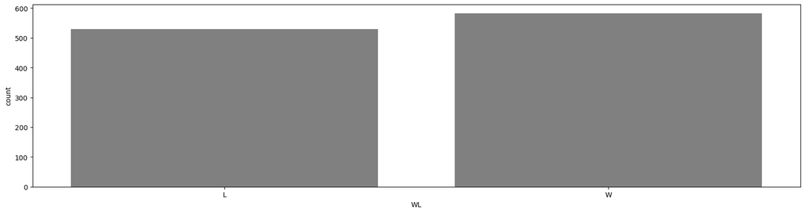

```python
sas_regular_season_totals = regular_season_totals[regular_season_totals["teamName"]=="San Antonio Spurs"]
uta_regular_season_totals = regular_season_totals[regular_season_totals["teamName"]=="Utah Jazz"]

plot_histogram("fieldGoalsMade",sas_regular_season_totals)
plot_histogram("fieldGoalsMade",uta_regular_season_totals)
sas_wl_bar_chart = plot_barchart("WL",sas_regular_season_totals)
uta_wl_bar_chart = plot_barchart("WL",uta_regular_season_totals)
```

[output not shown]

The histograms and bar charts above show that the San Antonio Spurs have a higher avergae number of field goals made while also more wins than Utah Jazz. To further investigate the association between field goals and winning, a 95% confidence interval for the true mean difference in field goals made is computed by bootstrap resampling with 1000 iterations from all NBA games during 2010-2024 when San Antonio Spurs beat Utah Jazz.

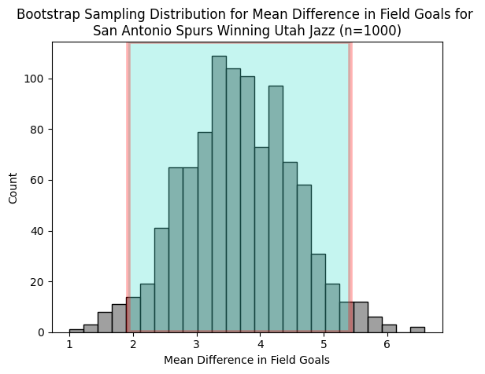

```
[1.9301724137931036, 5.414655172413792]
```

```python
np.random.seed(100)

combined_games_regular_season = pd.merge(winning_games_regular_season,losing_games_regular_season,on=["gameID"])
combined_games_regular_season["diffFieldGoals"] = combined_games_regular_season["fieldGoalsMade_x"] -  combined_games_regular_season["fieldGoalsMade_y"]

combined_games_play_offs = pd.merge(winning_games_play_offs,losing_games_play_offs,on=["gameID"])
combined_games_play_offs["diffFieldGoals"] = combined_games_play_offs["fieldGoalsMade_x"] -  combined_games_play_offs["fieldGoalsMade_y"]

sas_uta_games = combined_games_regular_season[(combined_games_regular_season["teamName_x"]=="San Antonio Spurs") & (combined_games_regular_season["teamName_y"]=="Utah Jazz")]

sas_uta_field_goals_bootstrap_distribution = bootstrap_distribution("diffFieldGoals",sas_uta_games)

sas_uta_percentile_confidence_interval = confidence_interval(sas_uta_field_goals_bootstrap_distribution)

plt.xlabel("Mean Difference in Field Goals")
plt.title("Bootstrap Sampling Distribution for Mean Difference in Field Goals for \nSan Antonio Spurs Winning Utah Jazz (n=1000)")

sas_uta_field_goals_confidence_interval = visualize_confidence_interval(sas_uta_field_goals_bootstrap_distribution,sas_uta_percentile_confidence_interval)

sas_uta_percentile_confidence_interval
```

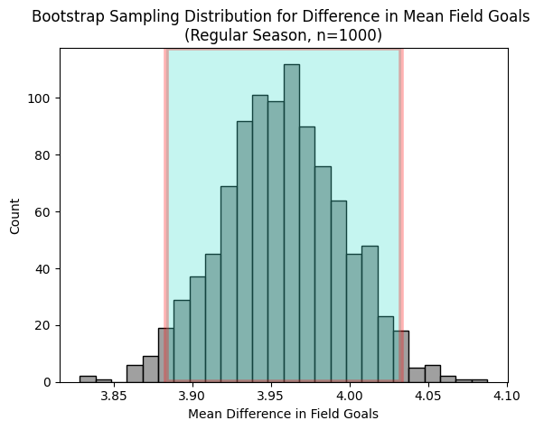

```
[3.883704526353704, 4.0328415776203625]
```

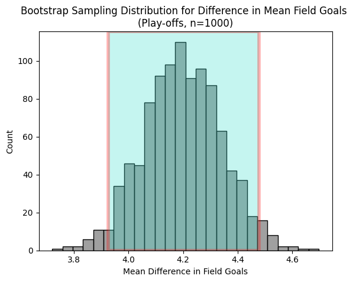

```
[3.925124688279302, 4.479093931837074]
```

```python
np.random.seed(100)

field_goals_regular_season_bootstrap_distribution = bootstrap_distribution("diffFieldGoals",combined_games_regular_season)

field_goals_regular_season_percentile_confidence_interval = confidence_interval(field_goals_regular_season_bootstrap_distribution)

plt.xlabel("Mean Difference in Field Goals")
plt.title("Bootstrap Sampling Distribution for Difference in Mean Field Goals \n(Regular Season, n=1000)")

field_goals_regular_season_confidence_interval = visualize_confidence_interval(field_goals_regular_season_bootstrap_distribution,field_goals_regular_season_percentile_confidence_interval)
print(field_goals_regular_season_percentile_confidence_interval)

field_goals_play_offs_bootstrap_distribution = bootstrap_distribution("diffFieldGoals",combined_games_play_offs)

field_goals_play_offs_percentile_confidence_interval = confidence_interval(field_goals_play_offs_bootstrap_distribution)

plt.xlabel("Mean Difference in Field Goals")
plt.title("Bootstrap Sampling Distribution for Difference in Mean Field Goals \n(Play-offs, n=1000)")

field_goals_play_offs_confidence_interval = visualize_confidence_interval(field_goals_play_offs_bootstrap_distribution,field_goals_play_offs_percentile_confidence_interval)
print(field_goals_play_offs_percentile_confidence_interval)
```

The results from constructing a 95% confidence interval for the true mean difference in field goals made using the both the regular season and play-offs samples further support the suggestion that field goals made are essential to success in basketball games, as the confidence interval for regular season games ranges from approximately 3.88 to 4.03 field goals. The confidence interval constructed from the play-offs games ranges similar values, but is a little wider. This is expected as the sample size is smaller than the regular season sample. The lower bounds reflect a larger difference in field goals compared to the interval for the San Antonio Spurs and Utah Jazz; both intervals are narrower, indicating more precision. The increased precision is expected, given the larger sample sizes.

#### Three Pointers

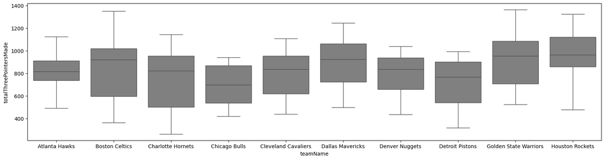

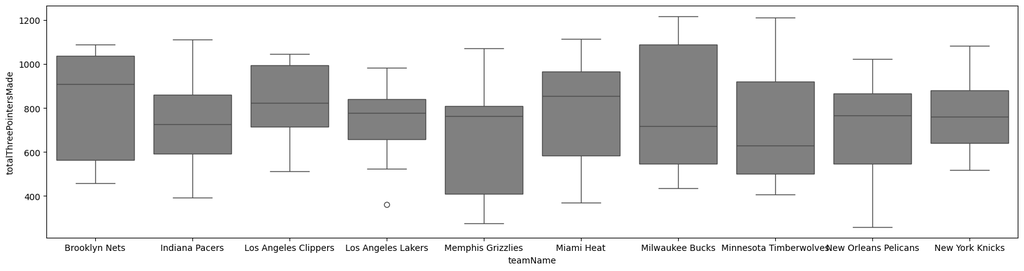

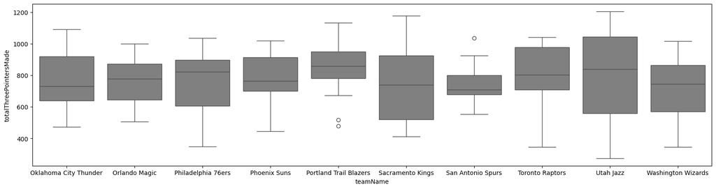

```python
plot_boxplot("totalThreePointersMade",regular_season_team_summary_stats_1)
plot_boxplot("totalThreePointersMade",regular_season_team_summary_stats_2)
plot_boxplot("totalThreePointersMade",regular_season_team_summary_stats_3)
```

Though San Antonio Spurs performs strongly in field goals, based on the boxplots, it seems like they do not perform as well in three pointers. On the contrary, Houston Rockets seems to perform better than the other teams in three pointers.

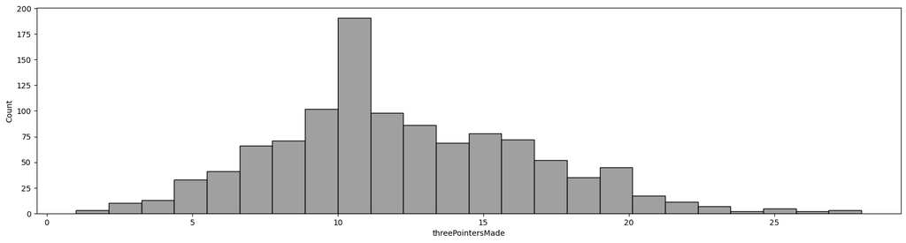

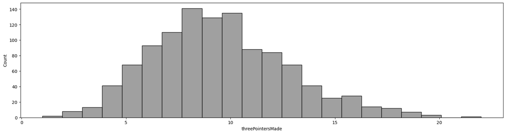

```python
hou_regular_season_totals = regular_season_totals[regular_season_totals["teamName"]=="Houston Rockets"]

plot_histogram("threePointersMade",hou_regular_season_totals)
plot_histogram("threePointersMade",sas_regular_season_totals)
plot_barchart("WL",hou_regular_season_totals)
plot_barchart("WL",sas_regular_season_totals)
```

[output not shown]

It is observed above that though Houston Rockets tend to make more three pointers than San Antonio Spurs, they do not have more wins.

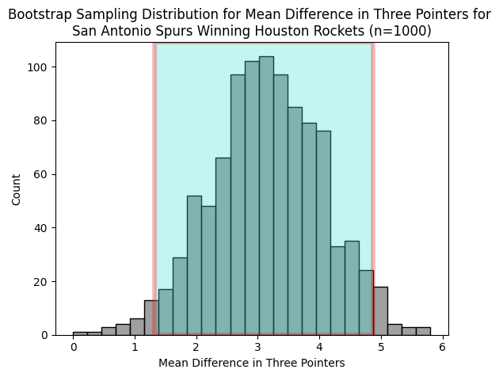

```
[1.32, 4.88]
```

```python
np.random.seed(100)

combined_games_regular_season["diffThreePointers"] = combined_games_regular_season["threePointersMade_x"] - combined_games_regular_season["threePointersMade_y"]
combined_games_play_offs["diffThreePointers"] = combined_games_play_offs["threePointersMade_x"] - combined_games_play_offs["threePointersMade_y"]


sas_hou_games = combined_games_regular_season[(combined_games_regular_season["teamName_x"] == "Houston Rockets") & (combined_games_regular_season["teamName_y"] == "San Antonio Spurs")]

sas_hou_field_goals_bootstrap_distribution = bootstrap_distribution("diffThreePointers",sas_hou_games)

sas_hou_percentile_confidence_interval = confidence_interval(sas_hou_field_goals_bootstrap_distribution)


plt.xlabel("Mean Difference in Three Pointers")
plt.title("Bootstrap Sampling Distribution for Mean Difference in Three Pointers for \nSan Antonio Spurs Winning Houston Rockets (n=1000)")
sas_hou_field_goals_confidence_interval = visualize_confidence_interval(sas_hou_field_goals_bootstrap_distribution,sas_hou_percentile_confidence_interval)
plt.show()

sas_hou_percentile_confidence_interval
```

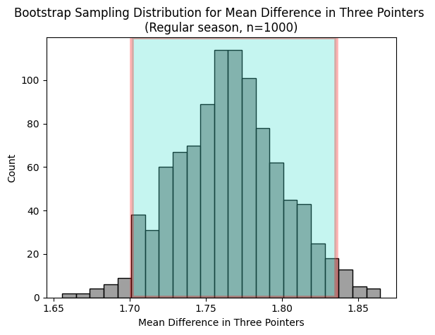

```
[1.7015848241085365, 1.8355249729859529]
```

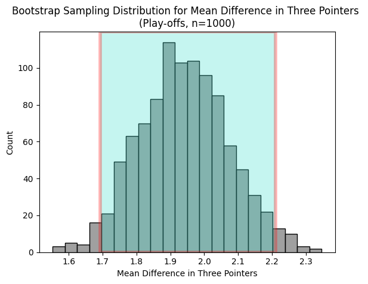

```
[1.693246051537822, 2.2103075644222776]
```

```python
np.random.seed(100)

three_pointers_regular_season_bootstrap_distribution = bootstrap_distribution("diffThreePointers",combined_games_regular_season)

three_pointers_regular_season_percentile_confidence_interval = confidence_interval(three_pointers_regular_season_bootstrap_distribution)

plt.xlabel("Mean Difference in Three Pointers")
plt.title("Bootstrap Sampling Distribution for Mean Difference in Three Pointers \n(Regular season, n=1000)")
three_pointers_regular_season_confidence_interval = visualize_confidence_interval(three_pointers_regular_season_bootstrap_distribution,three_pointers_regular_season_percentile_confidence_interval)
print(three_pointers_regular_season_percentile_confidence_interval)

three_pointers_play_offs_bootstrap_distribution = bootstrap_distribution("diffThreePointers",combined_games_play_offs)

three_pointers_play_offs_percentile_confidence_interval = confidence_interval(three_pointers_play_offs_bootstrap_distribution)

plt.xlabel("Mean Difference in Three Pointers")
plt.title("Bootstrap Sampling Distribution for Mean Difference in Three Pointers \n(Play-offs, n=1000)")
three_pointers_play_offs_confidence_interval = visualize_confidence_interval(three_pointers_play_offs_bootstrap_distribution,three_pointers_play_offs_percentile_confidence_interval)
print(three_pointers_play_offs_percentile_confidence_interval)
```

Using the regular season sample, the 95% confidence interval ranges from approximately 1.70 to 1.84 three-pointers. The play-offs sample also constructs an interval ranging similar values, except it is once again a little wider. Comparing these observations to field goals, it is clear that though there is indication that three-pointers are positively associated with winning, it is not as strong as field goals. This finding supports the idea that field goals are more critical than three-pointers in determining game outcomes.

#### Free Throws

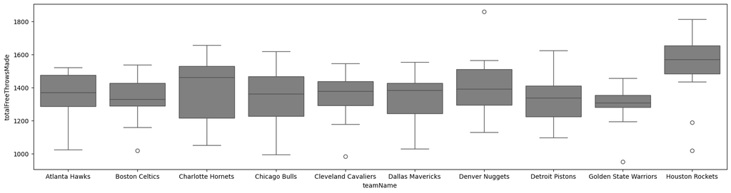

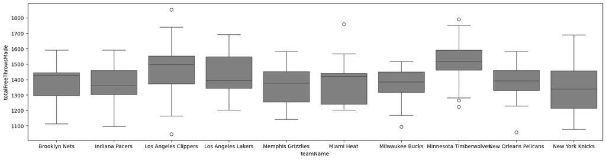

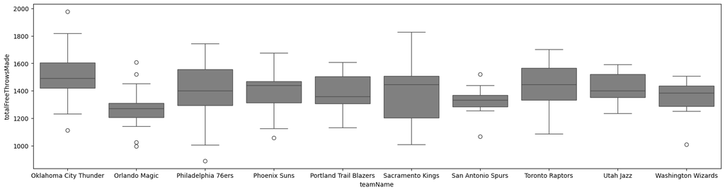

```python
plot_boxplot("totalFreeThrowsMade",regular_season_team_summary_stats_1)
plot_boxplot("totalFreeThrowsMade",regular_season_team_summary_stats_2)
plot_boxplot("totalFreeThrowsMade",regular_season_team_summary_stats_3)
```

For free throws made, it seems that Houston Rockets once again performs relatively better than the other teams. Orlando Magic seems to perform relatively worse.

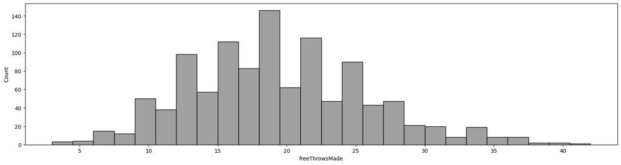

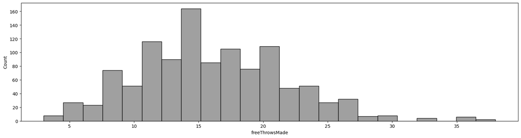

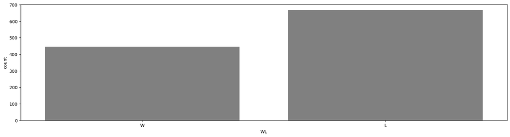

```python
orl_regular_season_totals = regular_season_totals[regular_season_totals["teamName"]=="Orlando Magic"]

plot_histogram("freeThrowsMade",hou_regular_season_totals)
plot_histogram("freeThrowsMade",orl_regular_season_totals)
plot_barchart("WL",hou_regular_season_totals)
plot_barchart("WL",orl_regular_season_totals)
```

[output not shown]

Not only does Orlando Magic make roughly less free throws, but it also loses more games than it wins.

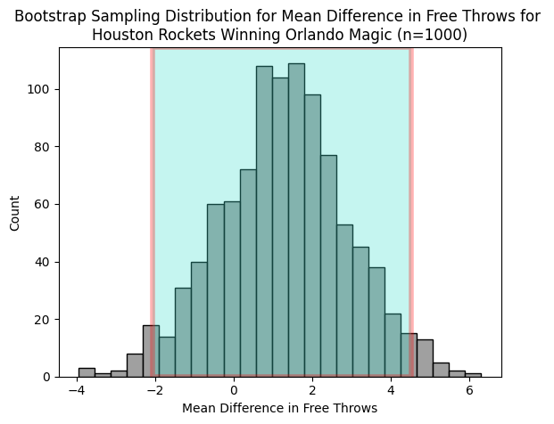

```
[-2.0588235294117645, 4.529411764705882]
```

```python
np.random.seed(100)

combined_games_regular_season["diffFreeThrows"] = combined_games_regular_season["freeThrowsMade_x"] - combined_games_regular_season["freeThrowsMade_y"]

combined_games_play_offs["diffFreeThrows"] = combined_games_play_offs["freeThrowsMade_x"] - combined_games_play_offs["freeThrowsMade_y"]


hou_orl_games = combined_games_regular_season[(combined_games_regular_season["teamName_x"]=="Houston Rockets") & (combined_games_regular_season["teamName_y"]=="Orlando Magic")]

hou_orl_free_throws_bootstrap_distribution = bootstrap_distribution("diffFreeThrows",hou_orl_games)

hou_orl_free_throws_percentile_confidence_interval = confidence_interval(hou_orl_free_throws_bootstrap_distribution)

plt.xlabel("Mean Difference in Free Throws")
plt.title("Bootstrap Sampling Distribution for Mean Difference in Free Throws for \nHouston Rockets Winning Orlando Magic (n=1000)")
hou_orl_free_throws_confidence_interval = visualize_confidence_interval(hou_orl_free_throws_bootstrap_distribution,hou_orl_free_throws_percentile_confidence_interval)

hou_orl_free_throws_percentile_confidence_interval
```

Despite the Houston Rockets making more free throws and wins than the Orlando Magic, the 95% confidence interval not only contains values below both 1 and 0. This implies that in a substantial number of games, the Orlando Magic may have made more free throws than the Houston Rockets, and additionally, there is limited confidence that the true mean difference in free throws made is above 0. This suggests that there is a weak relationship between making free throws and winning.

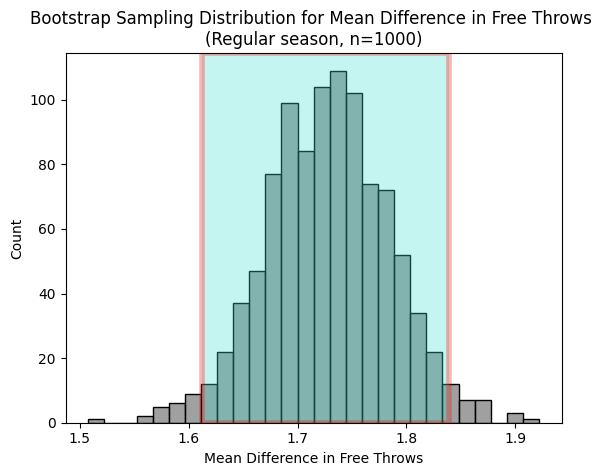

```
[1.6124894945371593, 1.8389317445071438]
```

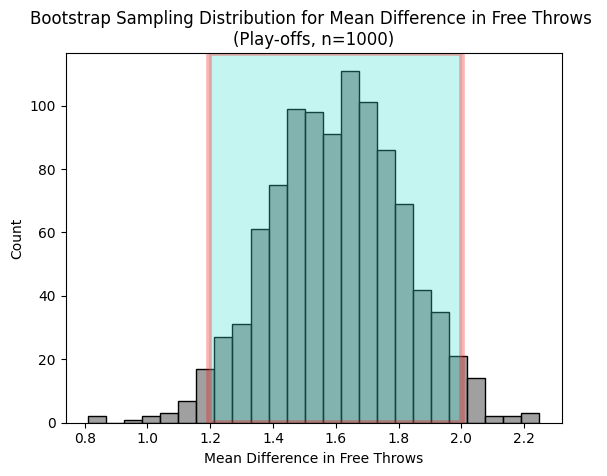

```
[1.1953241895261846, 2.0034081463009143]
```

```python
np.random.seed(100)

free_throws_regular_season_bootstrap_distribution = bootstrap_distribution("diffFreeThrows",combined_games_regular_season)

free_throws_regular_season_percentile_confidence_interval = confidence_interval(free_throws_regular_season_bootstrap_distribution)

plt.xlabel("Mean Difference in Free Throws")
plt.title("Bootstrap Sampling Distribution for Mean Difference in Free Throws \n(Regular season, n=1000)")
free_throws_regular_season_confidence_interval = visualize_confidence_interval(free_throws_regular_season_bootstrap_distribution,free_throws_regular_season_percentile_confidence_interval)
print(free_throws_regular_season_percentile_confidence_interval)

free_throws_play_offs_bootstrap_distribution = bootstrap_distribution("diffFreeThrows",combined_games_play_offs)

free_throws_play_offs_percentile_confidence_interval = confidence_interval(free_throws_play_offs_bootstrap_distribution)

plt.xlabel("Mean Difference in Free Throws")
plt.title("Bootstrap Sampling Distribution for Mean Difference in Free Throws \n(Play-offs, n=1000)")
free_throws_play_offs_confidence_interval = visualize_confidence_interval(free_throws_play_offs_bootstrap_distribution,free_throws_play_offs_percentile_confidence_interval)
print(free_throws_play_offs_percentile_confidence_interval)
```